# Optimization - Part1

## Topic 1

#### Determining Convexity

1) $F( x) =\frac{1}{x}\int_{0}^{x}\!f(t) \ dt \ $ where $f\!:\mathbb{R}\rightarrow{}\mathbb{R}$ is convex.

$\begin{array}{l} \text{if we set} \ t\ =\ xy\text{, and } x=\theta u +( 1-\theta ) v\ \text{ then,}\\ \ F( \theta u+( 1-\theta ) v) =\int _{0}^{1} f(( \theta u+( 1-\theta ) v) y) \ dy\\ \underset{\text{Jensen's}}{\leqslant } \\ \int _{0}^{1}( \theta f( uy) +( 1-\theta ) f( vy)) \ dy\ =\ \theta F( u) +( 1-\theta ) F( v)\\ F( \theta u+( 1-\theta ) v) \ \leqslant \ \theta F( u) +( 1-\theta ) F( v) \ \therefore \ F \ \text{is convex by definition.} \end{array}$

2) $\displaystyle f_{\theta }( x) =\theta ^{-1} x^{\theta } -\theta ^{-1}$ with $\displaystyle \text{dom} \ f_{\theta } =\mathbb{R}_{+}$ and $\displaystyle 0< \theta \leqslant 1$.

$\begin{array}{l} f_{\theta }^{''}( x) =( \theta -1) x^{\theta -2}\text{, since} \ f_{\theta }^{''}( x) \leqslant 0\text{, } f_{\theta } \ \text{is not convex.} \end{array}$

3) $\displaystyle f( x_{1} ,x_{2}) =\frac{x_{1}^{2}}{x_{2}}$ and $\displaystyle x_{2} >0$

$\begin{array}{l} \text{for } \ \mathbf{H}_{f} =\begin{bmatrix} \frac{2}{x_{2}} & -\frac{2x_{1}}{x_{2}^{2}}\\ -\frac{2x_{1}}{x_{2}^{2}} & \frac{2x_{1}^{2}}{x_{2}^{3}} \end{bmatrix}\text{, since} \ \frac{2}{x_{2}} >0\text{, and }\frac{2x_{1}^{2}}{x_{2}^{3}} \geqslant 0\ \text{ for } x_{2} >0\\ \text{the Hessian matrix of f is positive semidefinite.} \therefore \ f\ \text{ is convex.} \end{array}$

4) $\displaystyle f( x_{1} ,x_{2} ,x_{3}) =-e^{-x_{1}} +x_{2} x_{3}^{2}$

$\begin{array}{l} \text{for } \ \mathbf{H}_{f} =\begin{bmatrix} -e^{-x_{1}} & 0 & 0\\ 0 & 0 & 2x_{3}\\ 0 & 2x_{3} & 2x_{2} \end{bmatrix}\text{, and } g^{T}\mathbf{H} g=6x_{2} x_{3}^{2} -e^{-x_{1}} x_{1}^{2}\\ \text{the Hessian matrix of f is not positive semidefinite. } \ \therefore \ f\ \text{ is not convex.} \end{array}$

## Topic 2

#### Likelihood function, log-likelihood, gradient, and Hessian

Likelihood function $F$ where $c$ and $k$ are positive numbers, and $\displaystyle y_{i}$ can be found in "Topic2.csv" is defined as: \begin{align*} L( k,c;\ y_{1} ,...,y_{n}) &=\prod _{i=1}^{n}\frac{k\ c\ y_{i}^{c-1}}{\left( 1+y_{i}^{c}\right)^{k+1}} \\ &=( k\ c)^{n}\prod _{i=1}^{n}\frac{y_{i}^{c-1}}{\left( 1+y_{i}^{c}\right)^{k+1}} \end{align*}

a) log-likelihood:

\begin{array}{l} \log( L( k,c;\ y_{i})) \ =\ \log\left(( k\ c)^{n}\right) +\sum _{i=1}^{n}\frac{\log\left( y_{i}^{c-1}\right)}{\log\left(\left( 1+y_{i}^{c}\right)^{k+1}\right)}\\ \ell ( k,c;\ y_{i}) =\ n\log( k\ c) +( c-1)\sum _{i=1}^{n}\log\left( y_{i}\right) -( k+1)\sum _{i=1}^{n}\log\left( 1+y_{i}^{c}\right) \end{array}

b) Maximum Likelihood Estimate:

\begin{equation*} \text{for} \ \theta =\{k,c\}\text{, }\hat{\theta }_{MLE} =\underset{\theta }{\arg\max} L( y_{i} |\theta ) =\underset{\theta }{\arg\max} \ell ( y_{i} |\theta ) \end{equation*}

c) Gradient:

\begin{array}{l} \frac{\partial }{\partial k} \ell ( k,c;\ y_{i}) =\frac{n}{k} -\sum _{i=1}^{n}\log\left( 1+y_{i}^{c}\right)\\ \begin{align*} \frac{\partial }{\partial c} \ell ( k,c;\ y_{i}) &= \frac{n}{c} +\sum _{i=1}^{n}\log\left( y_{i}\right) -( k+1)\sum _{i=1}^{n}\frac{y_{i}^{c}\log( y_{i})}{1+y_{i}^{c}} \\ &= \frac{n}{c} +\sum _{i=1}^{n}\frac{\left( 1-k\ y_{i}^{c}\right)\log( y_{i})}{y_{i}^{c} +1} \end{align*} \end{array}

Hessian:

\begin{equation*} \mathbf{H}_{\ell _{\{k,c\}}} =\begin{bmatrix} \frac{\partial ^{2} \ell }{\partial k^{2}} & \frac{\partial ^{2} \ell }{\partial k\partial c}\\ \frac{\partial ^{2} \ell }{\partial c\partial k} & \frac{\partial ^{2} \ell }{\partial c^{2}} \end{bmatrix} =\begin{bmatrix} -\frac{n}{k^{2}} & -\sum _{i=1}^{n}\frac{y_{i}^{c}\log( y_{i})}{y_{i}^{c} +1}\\ -\sum _{i=1}^{n}\frac{y_{i}^{c}\log( y_{i})}{y_{i}^{c} +1} & -\frac{n}{c^{2}} -( k+1)\sum _{i=1}^{n}\frac{y_{i}^{c}\log^{2}( y_{i})}{\left( y_{i}^{c} +1\right)^{2}} \end{bmatrix} \end{equation*}

```python
import cmath as cm
import numpy as np
import matplotlib.pyplot as plt
```

```python
y = np.loadtxt('Topic2.csv', delimiter=',')
```

```python
def ell(kc, y):
    k, c, n = kc[0], kc[1], y.shape[0]
    return n * np.real(cm.log(k * c)) + (c - 1) * np.sum(np.log(y)) - (k + 1) * np.sum(np.log(1 + y ** c))
```

```python
def grad_kc(kc, y):
    k, c, n = kc[0], kc[1], y.shape[0]
    grad_k = (n / k) - np.sum(np.log(1 + y ** c))
    grad_c = (n / c) + np.sum(((1 - k * y ** c) * np.log(y)) / (y ** c + 1))

    return np.array([grad_k, grad_c])
```

```python
def hess_kc(kc, y):
    k, c, n = kc[0], kc[1], y.shape[0]
    k_gg = -(n/k**2)
    c_gg = -(n/c**2)-(k+1)*(np.sum((y**c)*(np.log(y**c)**2)/(y**c+1)**2))
    kc_gg = -np.sum((y**c)*np.log(y**c)/(y**c+1))
    return np.array([[k_gg, kc_gg], [kc_gg, c_gg]])
```

```python
def plot(kc_list, conv_list, f_list):
    kc_mle = np.round(kc_list[-1], 3).tolist()
    print('Results converged in', f_list.size, 'iterations.',
          '\nk^ MLE:', kc_mle[0], '\nc^ MLE: ', kc_mle[1],
          '\nlog-likelihood:', np.round(f_list[-1],2))
    fig, ax = plt.subplots(2, 2, figsize=(10, 10))
    fig.suptitle('Plots of Params vs Number of Iterations', fontsize=16)
    ax[0, 0].plot(kc_list[:, 0]), ax[0, 0].set_title(r'$\hat{k}$ estimates')
    ax[0, 1].plot(kc_list[:, 1]), ax[0, 1].set_title(r'$\hat{c}$ estimates')
    ax[1, 0].plot(f_list), ax[1, 0].set_title(r'$\ell(c,k;y_i)$')
    ax[1, 1].plot(conv_list), ax[1, 1].set_title('Convergence')
    plt.tight_layout()
    plt.show()
```

#### Gradient Descent with Backtracking Line Search

```python
def gDwBt(y, alpha=1, beta=0.1, max_iter=500, tol=1e-5, rs=0):
    np.random.seed(rs)
    kc0 = np.random.randn(2)
    ell0 = ell(kc0, y)
    grad_ = grad_kc(kc0, y)
    conv_l = [grad_ @ grad_]
    kc_l = [kc0]
    f_l = [ell0]

    for i in range(max_iter):
        kc = kc0 + alpha * grad_kc(kc0, y)
        ell_new = ell(kc, y)
        while ell_new < ell0:
            alpha = beta * alpha
            kc = kc0 + alpha * grad_
            ell_new = ell(kc, y)

        kc0 = kc + alpha * grad_
        ell0 = ell(kc0, y)
        grad_ = grad_kc(kc0, y)

        conv_l.append(grad_ @ grad_)
        kc_l.append(kc0)
        f_l.append(ell0)

        if np.abs(conv_l[-1]) < tol:
            break

    return np.array(kc_l), np.array(conv_l), np.array(f_l)
```

```
Results converged in 401 iterations.
k^ MLE: 8.948
c^ MLE:  3.556
log-likelihood: 795.46
```

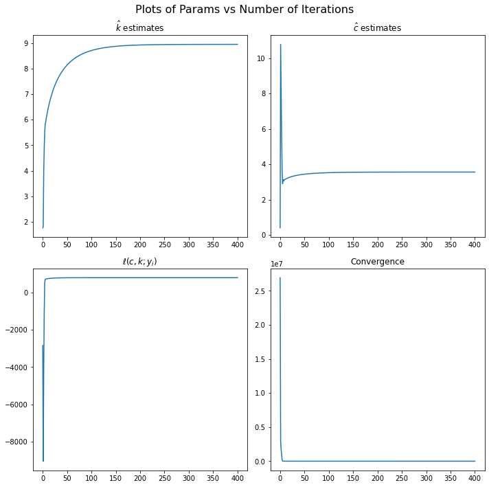

```python
kc_list, conv_list, f_list = gDwBt(y)
plot(kc_list, conv_list, f_list)
```

#### Accelerated Gradient Descent (+ Backtracking Line Search)

```python
def agDwBt(y, alpha=0.001, beta=0.01, max_iter=500, tol=1e-5, rs=0):
    np.random.seed(rs)
    kc0 = np.random.randn(2)
    kc_2 = np.random.randn(2)
    ell0 = ell(kc0, y)
    kc = kc0
    grad_ = grad_kc(kc0, y)
    conv_l = [grad_ @ grad_]
    kc_l = [kc0]
    f_l = [ell0]
    k=1

    for i in range(max_iter):
        ell_new = ell(kc, y)
        while ell_new < ell0:
            alpha = alpha/beta
            kc_ = kc_2 + alpha * grad_
            ell_new = ell(kc_, y)

        kc0 = kc_2 + alpha * grad_
        kc_2 = kc0 + (k-1)/(k+2) * (kc0 - kc)
        ell0 = ell(kc0, y)
        grad_ = grad_kc(kc_2, y)

        kc = kc0
        k+=1

        conv_l.append(grad_ @ grad_)
        kc_l.append(kc0)
        f_l.append(ell0)

        if np.abs(conv_l[-1]) < tol:
            break

    return np.array(kc_l), np.array(conv_l), np.array(f_l)
```

```
Results converged in 151 iterations.
k^ MLE: 8.945
c^ MLE:  3.556
log-likelihood: 795.46
```

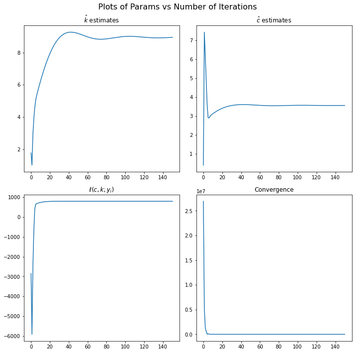

```python
kc_list, conv_list, f_list = agDwBt(y)
plot(kc_list, conv_list, f_list)
```

#### Stochastic Gradient Descent (+ Backtracking Line Search)

(also includes convergence mean change test)

```python
def sgDwBt(y, alpha=1, beta=0.2, bsize=0.2, max_iter=500, tol=1e-4, rs=0):
    np.random.seed(rs)
    cap = int(bsize * len(y))

    kc0 = np.random.randn(2)
    y_ = np.random.choice(y, cap, replace=False)
    ell0 = ell(kc0, y_)
    grad_ = grad_kc(kc0, y_)
    conv_l = [grad_ @ grad_]
    kc_l = [kc0]
    f_l = [ell0]

    for i in range(max_iter):
        kc = kc0 + alpha * grad_kc(kc0, y_)
        ell_new = ell(kc, y_)
        while ell_new < ell0 and alpha > 0.009:
            alpha = alpha * beta
            kc = kc0 + alpha * grad_
            ell_new = ell(kc, y_)+alpha

        kc0 = kc + alpha * grad_
        ell0 = ell(kc0, y_)
        grad_ = grad_kc(kc0, y_)
        y_ = np.random.choice(y, cap, replace=False)

        conv_l.append(grad_ @ grad_)
        kc_l.append(kc0)
        f_l.append(ell0)

        if len(conv_l) > (max_iter/10 + 15):
            changecontrol = np.abs(np.mean(conv_l[-11:-1]) - np.mean(conv_l[-16:-5]))/1e3
            if changecontrol < tol:
                break

    kc_l.append(np.mean(kc_list[-5:-1], axis=0))
    f_l.append(np.mean(f_l[-5:-1]))
    conv_l.append(np.mean(conv_l[-11:-1]))

    return np.array(kc_l), np.array(conv_l), np.array(f_l)*(bsize*100)
```

```
Results converged in 219 iterations.
k^ MLE: 8.938
c^ MLE:  3.555
log-likelihood: 809.55
```

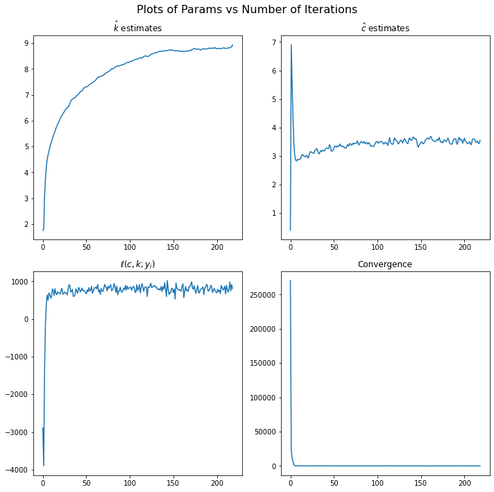

```python
kc_list, conv_list, f_list = sgDwBt(y, alpha=0.1, beta=0.5, bsize=0.1)
plot(kc_list, conv_list, f_list)
```

#### Newton's Method (+ Backtracking Line Search)

```python
# newton's method with line search
def newton(y, beta=0.9, max_iter=500, tol=1e-6):
    kc0 = np.array([0.5,0.5])
    ell0 = ell(kc0, y)
    grad_ = grad_kc(kc0, y)
    hess_inv = np.linalg.inv(hess_kc(kc0, y))
    conv_l = [grad_ @ grad_]
    kc_l = [kc0]
    f_l = [ell0]
    alph_ = 1

    for i in range(max_iter):
        kc = kc0 - alph_ * hess_inv @ grad_

        ell_new = ell(kc, y)
        while ell_new < ell0:
            alph_ = beta * alph_
            kc = kc0 - alph_ * hess_inv @ grad_
            ell_new = ell(kc, y)

        kc0 = kc - alph_ * hess_inv @ grad_
        ell0 = ell(kc0, y)
        grad_ = grad_kc(kc0, y)
        hess_inv = np.linalg.inv(hess_kc(kc0, y))

        conv_l.append(grad_ @ grad_)
        kc_l.append(kc0)
        f_l.append(ell0)

        if np.log1p(np.abs(conv_l[-1]-conv_l[-2])) < tol:
            break

    return np.array(kc_l), np.array(conv_l), np.array(f_l)
```

```
Results converged in 197 iterations.
k^ MLE: 8.948
c^ MLE:  3.557
log-likelihood: 795.46
```

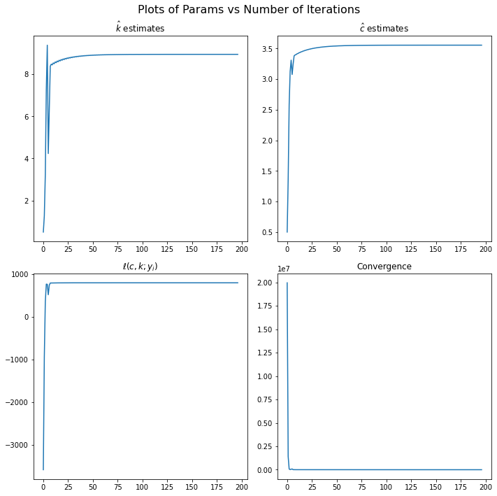

```python
kc_list, conv_list, f_list = newton(y)
plot(kc_list, conv_list, f_list)
```

## Topic 3

#### Loss Function

Minimizing the following loss function using Gauss-Newton method:

\begin{equation*} L( \beta ) =\underset{\beta _{1} ,\beta _{2}}{min}\sum _{i=1}^{n}\left( y_{i} -\frac{y_{1} \beta _{1}}{y_{1} +( \beta _{1} -y_{1})\exp( -\beta _{2} d_{i})}\right)^{2} \end{equation*}

`Topic3.csv` contains $d_i$ (first column) and $y_i$ (second column). Our goal is to estimate $\displaystyle \hat{\beta } =\begin{bmatrix} \hat{\beta }_{1} & \hat{\beta }_{2} \end{bmatrix}^{T}$.

To decompose $\displaystyle L( \beta )$ as $\displaystyle L( \beta ) =g^{T}( \beta ) g( \beta )$, we set $\displaystyle g( \beta ) =\left[\overset{\rightharpoonup }{y} -\frac{y_{1} \beta _{1}}{y_{1} +( \beta _{1} -y_{1})\exp\left( -\beta _{2}\overset{\rightharpoonup }{d}\right)}\right]$.

The Jacobian matrix $\displaystyle \mathbf{J}_{g}( \beta _{1} ,\beta _{2}) =\begin{bmatrix} \frac{\partial g_{1...n}( \beta )}{\partial \beta _{1}} & \frac{\partial g_{1...n}( \beta )}{\partial \beta _{2}} \end{bmatrix}$ is derived as:

\begin{align*} \mathbf{J}_{g} (\beta _{1} ,\beta _{2} ) & =\begin{bmatrix} -y_{1}\frac{\left( y_{1} +(\beta _{1} -y_{1} )e^{-\beta _{2} d}\right) -e^{-\beta _{2} d} \beta _{1}}{\left( y_{1} +(\beta _{1} -y)e^{-\beta _{2} d}\right)^{2}} & y_{1} \beta _{1}\frac{-de^{-d\beta _{2}} (\beta _{1} -y_{1} )}{\left( y_{1} +(\beta _{1} -y_{1} )e^{-\beta _{2} d}\right)^{2}} \end{bmatrix}\\ & =\begin{bmatrix} \frac{y_{1}^{2}\left( 1-e^{\beta _{2} d}\right) e^{\beta _{2} d}}{\left( \beta _{1} +y_{1} e^{\beta _{2} d} -y_{1}\right)^{2}} & \frac{y_{1} \beta _{1} d(y_{1} -\beta _{1} )e^{\beta _{2} d}}{\left( \beta _{1} +y_{1} e^{\beta _{2} d} -y_{1}\right)^{2}} \end{bmatrix} \end{align*}

```python
import numpy as np
import matplotlib.pyplot as plt

plt.rcParams['figure.dpi'] = 100
```

```python
dat = np.loadtxt('Topic3.csv', delimiter=',')
d, y = dat[:,0], dat[:,1]
```

```python
def f(beta):
    b1, b2, y1 = beta[0], beta[1], y[0]
    return np.sum((y-(y1*b1)/(y1+(b1-y1)*np.exp(-b2*d)))**2)

def g(beta):
    b1, b2, y1 = beta[0], beta[1], y[0]
    return np.array([y-(y1*b1)/(y1+(b1-y1)*np.exp(-b2*d))]).T

def J(beta):
    b1, b2, y1 = beta[0], beta[1], y[0]
    J1 = np.exp(b2*d)*(1-np.exp(b2*d))*y1**2/(b1+y1*np.exp(b2*d)-y1)**2
    J2 = np.exp(b2*d)*y1*b1*d*(y1-b1)/(b1+y1*np.exp(b2*d)-y1)**2
    return np.c_[J1, J2]
```

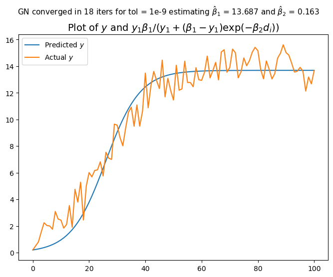

```python
beta0 = np.array([1, 1])
alpha, tol, max_iter=1, 1e-9, 500
g0 = g(beta0)
J0 = J(beta0)
f0 = f(beta0)
f_list = [f0]
Omega = -np.linalg.solve(J0.T@J0 +10*np.eye(2), J0.T@g0).T
while np.abs(Omega).max() > tol and len(f_list) < max_iter:
    beta_ = beta0 + alpha*Omega
    f_ = f(beta_.T)
    while f_ > f0:
        alpha = alpha*0.1
        beta_ = beta0 - alpha*Omega
        f_ = f(beta_.T)
    beta0 = beta_
    g0 = g(beta0.T)
    J0 = J(beta0.T)
    f0 = f_
    f_list.append(f0)
    Omega = -np.linalg.solve(J0.T@J0 +10*np.eye(2), J0.T@g0).T
y_pred = (y[0]*beta_.T[0])/(y[0]+(beta_.T[0]-y[0])*np.exp(-beta_.T[1]*d))
plt.figure(figsize=(8,6))

cap = r'GN converged in %s iters for tol = 1e-9 estimating ' %(len(f_list)-1)
beta_str = r'$\hat{\beta}_1$ = %2.3f and $\hat{\beta}_2$ = %2.3f'\
           %(beta_.T[0],beta_.T[1])
plt.plot(d, y_pred, label=r'Predicted $y$'), plt.plot(d, y, label=r'Actual $y$')
plt.suptitle(cap + beta_str, size=11)
plt.title(r'Plot of $y$ and $y_{1}\beta_{1}/(y_{1}+'
          r'(\beta_{1}-y_{1})\exp(-\beta_{2}d_{i}))$', size=14)
_= plt.legend(), plt.show()
```

## Topic 4

#### **Part 1**

Considering the following optimization problem:

\begin{equation*} \underset{x}{\min}\frac{1}{2} x^{T} Px+q^{T} x+\frac{\lambda }{2}\Vert z\Vert _{2}^{2} \ \quad \ s.t.\quad \ \begin{cases} x=z\\ a\leqslant z\leqslant b \end{cases} \ \quad \text{where} \ P\in \mathbb{R}^{n\times n} \ \text{and} \ a,b,x,q\in \mathbb{R}^{n} \end{equation*}

For the scaled form of the ADMM, $\mathcal{L}( x,z,w;\rho ) =f( x) +g( z) +\frac{\rho }{2}\Vert Ax+Bz-c+w\Vert _{2}^{2} +\frac{\rho }{2}\Vert w\Vert _{2}^{2}$ with $w=\frac{\mathcal{u}}{\rho}$ we have:

\begin{equation*} \begin{aligned} \{A,B,c\} & =\{1,-1,0\} \ \quad \text{, due } 1x-1z=0 & \text{(first constraint)}\\ \mathfrak{stc}\!_{::} \ \mathcal{z} & =\ \min\{b,\ \max\{a,\mathcal{z}\}\} \ \quad \text{, due } a\leqslant z\leqslant b & \text{(second constraint)}\\ f( x) & =\frac{1}{2} x^{T} Px+q^{T} x=\left(\frac{1}{2} x^{T} P+q^{T}\right) x & \\ g( z) & =\frac{\lambda }{2}\Vert z\Vert _{2}^{2} & \\ \mathcal{L}( x,z,w;\rho ) & =\left(\frac{1}{2} x^{T} P+q^{T}\right) x+\frac{\lambda }{2}\Vert z\Vert _{2}^{2} +\frac{\rho }{2}\Vert x-z+w\Vert _{2}^{2} +\frac{\rho }{2}\Vert w\Vert _{2}^{2} & \\ \text{with the following updates:} & & \\ x_{k} & =\arg\underset{x}{\min}\left(\frac{1}{2} x^{T} P+q^{T}\right) x+\frac{\rho }{2}( x-z_{k-1} +w_{k-1})^{2} & \\ z_{k} & =\mathfrak{stc}\!_{::}\arg\underset{z}{\min}\frac{\lambda }{2} z^{2} +\frac{\rho }{2}( x_{k} -z_{k-1} +w_{k-1})^{2} & \\ w_{k} & =w_{k-1} +x_{k} -z_{k} & \end{aligned} \end{equation*}

Now we can derive the gradients to get rid of $\arg\underset{\{x,\ z\}}{\min}$ in the update equations:

\begin{equation*} \begin{aligned} \text{for:} & \\ \frac{\partial }{\partial x} x_{k}^{\text{argmin} \langle *\rangle } & =\frac{1}{2}\left( P+P^{T}\right) x+q^{T} +\rho ( x-z_{k-1} +w_{k-1}) =0\\ \frac{\partial }{\partial z} z_{k}^{\text{argmin} \langle *\rangle } & =\lambda z-\rho ( x_{k} -z +w_{k-1}) =0\\ \text{we have} & \\ x_{k} & =2\left( \rho ( z_{k-1} -w_{k-1}) -q^{T}\right)\left( P +P^{T} +\rho \right)^{-1}\\ z_{k} & =\ \mathfrak{stc}_{::} \ \rho ( x_{k} +w_{k-1})( \lambda +\rho )^{-1}\\ w_{k} & =w_{k-1} +x_{k} -z_{k} \end{aligned} \end{equation*}

#### **Part 2**

Implementation:

```python
import scipy.io as sio
import matplotlib.pyplot as plt
import numpy as np
```

```python
# load data
data_mat = sio.loadmat('Topic4.mat')
P, q, a, b = data_mat['P'], data_mat['q'], data_mat['a'].T, data_mat['b'].T
lam, rho = 0.5, 1.1

max_iter = 50
tol = 1e-9 # tolerance for convergence

# Fully initialize x, z, and w for faster computation (instead of .append)
x = np.zeros((max_iter+1, a.size))
z = np.ones((max_iter+1, a.size)) * np.mean(np.r_[a, b], 0)
w = np.zeros((max_iter+1, a.size))
f_x = np.zeros(max_iter)
res = np.zeros(max_iter)
f_x_f = lambda X: 0.5 * X.T @ P @ X + q.T @ X

P_x = np.linalg.inv(P+P.T+rho)
G_z = rho/(lam+rho)

# ADMM
for i in range(max_iter):
    x[i+1] = 2 * (rho * (z[i] - w[i])-q.T) @ P_x
    z[i+1] = np.minimum(b, np.maximum(a, (x[i+1] + w[i]) * G_z))
    w[i+1] = w[i] + x[i+1] - z[i+1]
    f_x[i] = f_x_f(x[i+1])
    res[i] = np.linalg.norm(x[i+1]-z[i+1])
    if res[i] < tol: break
print('Algorithm converged in {} iterations with tolerance of {}.'.format(i+1, tol))
print('f(x) at convergence:', np.round(f_x[i],3))
```

```
Algorithm converged in 44 iterations with tolerance of 1e-09.
f(x) at convergence: 6.902
```

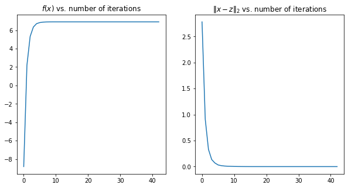

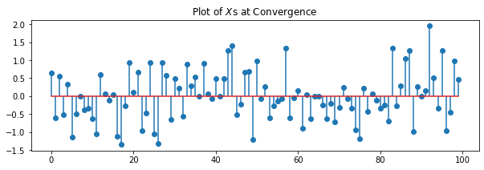

```python
plt.figure(figsize=(10,5)), plt.subplot(1,2,1), plt.plot(f_x[1:i+1])
plt.title(r'$f(x)$ vs. number of iterations'), plt.subplot(1,2,2)
plt.plot(res[1:i+1]), plt.title(r'$\Vert{x-z}\Vert_{2}$ vs. number of iterations')
plt.figure(figsize=(10,3)), plt.stem(x[i]), plt.title(r'Plot of $X$s at Convergence')
plt.show()
```

## Topic 5

### **Part 1:**

Considering the following (slightly modified) optimization of Ridge Regression penalized sum of squares, we solve for optimal $w_j$ using coordinate descent:

\begin{equation*} \begin{aligned} \text{for: } & \\ \underset{w}{\min F_{( w)}} & =\underset{w}{\min}\frac{1}{2}\Vert y-Xw\Vert _{2}^{2} +\frac{\lambda }{2}\Vert w\Vert _{2}^{2}\\ \text{we have: } & \\ F_{( w)} & =\frac{1}{2}\Vert y -\sum _{j=1}^{p} x_{j} w_{j}\Vert ^{2} +\frac{\lambda }{2}\sum _{j=1}^{p} w_{j}^{2} \ \\ \frac{\partial F_{( w)}}{\partial w_{j}} & =\left(\frac{1}{2}\right)( -2x_{j})\left( y -\sum _{k\neq j}^{p} w_{k} x_{k} -x_{j} w_{j}\right) +\left(\frac{\lambda }{2}\right) 2w_{j}\\ \text{If we set: } & r_{-j} =y -\sum _{k\neq j}^{p} w_{k} x_{k}\\ \frac{\partial F_{( w)}}{\partial w} & =-x_{j}( r_{-j} -w_{j} x_{j}) +\lambda w_{j} =0\ \ \ \rightarrow \\ w_{j} & =\frac{x_{j}^{T} r_{-j}}{x_{j}^{T} x_{j} +\lambda }\\ \text{and if we set: } & \tilde{x}_{j} =\frac{x_{j}}{\Vert x_{j}\Vert } \ \quad \text{we'll have:} \ \tilde{x}_{j}^{T}\tilde{x}_{j} =1\ \\ w_{j} & =\frac{\tilde{x}_{j}^{T} r_{-j}}{1+\lambda } ,\quad \text{where} \ r_{-j} =y -\sum _{k\neq j}^{p} w_{k}\tilde{x}_{k} \end{aligned} \end{equation*}

### **Part 2:**

Considering the following optimization, we solve for optimal $w_j$ using coordinate descent:

\begin{equation*} \begin{aligned} \text{for: } & \\ \underset{w}{\min F_{( w)}} & =\underset{w}{\min}\frac{1}{2}\Vert y-Xw\Vert _{2}^{2} +\lambda _{1}| w| _{1} +\frac{\lambda _{2}}{2}\Vert w\Vert _{2}^{2}\\ \text{we have: } & \\ F_{( w)} & =\frac{1}{2}\Vert y -\sum _{j=1}^{p} x_{j} w_{j}\Vert ^{2} +\frac{\lambda _{2}}{2}\sum _{j=1}^{p} w_{j}^{2} \ +\lambda _{1}\sum _{j=1}^{p}| w_{j}| \\ \frac{\partial F_{( w)}}{\partial w_{j}} & =-x_{j}\left( y -\sum _{k\neq j}^{p} w_{k} x_{k} -x_{j} w_{j}\right) +\lambda _{2} w_{j} +\lambda _{1}\text{sgn}( w_{j})\\ \text{If we set: } & r_{-j} =y -\sum _{k\neq j}^{p} w_{k} x_{k}\\ \frac{\partial F_{( w)}}{\partial w} & =-x_{j}( r_{-j} -w_{j} x_{j}) +\lambda _{2} w_{j} +\lambda _{1}\text{sgn}( w_{j}) =0\ \ \ \rightarrow \\ w_{j} & =\frac{x_{j}^{T} r_{-j} -\lambda _{1}\text{sgn}( w_{j})}{x_{j}^{T} x_{j} +\lambda _{2}} =\frac{\tilde{x}_{j}^{T} r_{-j} -\lambda _{1}\text{sgn}( w_{j})}{1+\lambda _{2}} \end{aligned} \end{equation*}

### **Part 3:**

Here we apply the regression algorithms we derived in the previous sections to train a model for predicting performance decay over time of the Gas Turbine compressor.

```python
import numpy as np
from numpy.linalg import norm
from numpy import delete as sans
import matplotlib.pyplot as plt
from sklearn.preprocessing import StandardScaler
```

```python
data = np.loadtxt('Topic5.csv', delimiter=',')
X_train, y_train = data[:2000, :-1], data[:2000, -1]
X_test, y_test = data[2000:, :-1], data[2000:, -1]

# Regularization, Normalization and added column of ones for intercept
scaler = StandardScaler()
X_train2 = scaler.fit_transform(X_train)
X_test2 = scaler.transform(X_test)
X_train2 = np.c_[np.ones(X_train2.shape[0]), X_train]
X_test2 = np.c_[np.ones(X_test2.shape[0]), X_test]
X_norms = norm(X_train2, axis=0)
X_norms = np.where(X_norms == 0, 1, X_norms)
X_train_ = X_train2 / X_norms  # Normalization
X_test_ = X_test2 / X_norms
```

```python
res_ = lambda W: norm(y_train - X_train_ @ W)**2
r_j_ = lambda J, W: y_train - sans(X_train_, J, axis=1) @ sans(W, J)
```

```python
def coordescent(wfunc, max_iter = 500):
    w = np.log1p(norm(X_train_, axis=0)**0.5)  # instead of a seed
    res = np.zeros(max_iter)
    for i in range(max_iter):
        for j in range(w.size):
            r_j = r_j_(j, w)
            w[j] = wfunc(r_j, j, w)
        res[i] = res_(w)
    return w, res
```

##### Implementation of **Part 1:**

With predefined requirements:

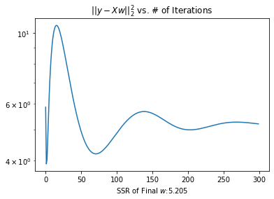

```
Values of 'w' at Convergence:
[ 9.83  0.72  0.62 -2.37  3.66  7.45 -2.99  5.82  7.86  2.12  2.38  9.61
 -1.42 -1.52]
```

```python
lam = 0.1
w_p1_ = lambda R, J, W: (X_train_[:,J].T @ R) / (1+lam)
w_p1, res_p1 = coordescent(w_p1_, max_iter=300)
plt.plot(res_p1), plt.yscale('log')
plt.title(r'$||y-Xw||_{2}^{2}$ vs. # of Iterations')
plt.xlabel(r'SSR of Final $w$:%2.3f' %(res_p1[-1]))
plt.show()
print('Values of \'w\' at Convergence:')
print(np.round(w_p1,2))
```

```python
SAE_tst_p1 = np.sum(np.abs(y_test - X_test_ @ w_p1))
print('SAE of the Test Set: %3.3f' % SAE_tst_p1)
```

```
SAE of the Test Set: 16.383
```

With some optimizations:

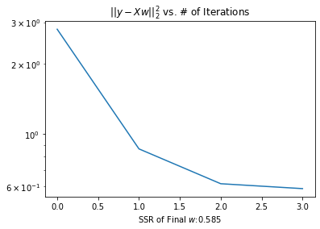

```
Values of 'w' at Convergence:
[35.57 -0.41  0.62 -0.41  2.32  1.81 -1.89  2.44  1.18 -0.37  0.72  2.
 -1.1   0.63]
```

```python
lam = 0.01
w_p1_ = lambda R, J, W: (X_train_[:,J].T @ R) / (1+lam)
w_p1, res_p1 = coordescent(w_p1_, max_iter=4)  # Catching the first dip.
plt.plot(res_p1), plt.yscale('log')
plt.title(r'$||y-Xw||_{2}^{2}$ vs. # of Iterations')
plt.xlabel(r'SSR of Final $w$:%2.3f' %(res_p1[-1]))
plt.show()
print('Values of \'w\' at Convergence:')
print(np.round(w_p1,2))
```

```python
SAE_tst_p1 = np.sum(np.abs(y_test - X_test_ @ w_p1))
print('SAE of the Test Set: %3.3f' % SAE_tst_p1)
```

```
SAE of the Test Set: 5.217
```

##### Implementation of **Part 2:**

With predefined requirements:

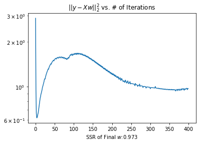

```
[ 1.178e+01 -1.000e-02 -5.300e-01 -3.840e+00  3.000e-02  5.760e+00
 -8.300e-01  5.680e+00  1.051e+01  2.000e-01  2.800e-01  1.358e+01
  1.000e-02  1.000e-02]
```

```python
lam1 = 0.05
lam2 = 0.01
w_p2_ = lambda R, J, W: (X_train_[:,J].T @ R - lam1*np.sign(W[J])) / (1+lam2)
w_p2, res_p2 = coordescent(w_p2_, max_iter=400)
plt.plot(res_p2), plt.yscale('log')
plt.title(r'$||y-Xw||_{2}^{2}$ vs. # of Iterations')
plt.xlabel(r'SSR of Final $w$:%2.3f' %(res_p2[-1]))
plt.show()
print('Values of \'w\' at Convergence:')
print(np.round(w_p2,decimals=2))
```

```python
SAE_tst_p2 = np.sum(np.abs(y_test - X_test_ @ w_p2))
print('SAE of the Test Set: %3.3f' % SAE_tst_p2)
```

```
SAE of the Test Set: 6.858
```

With some optimizations:

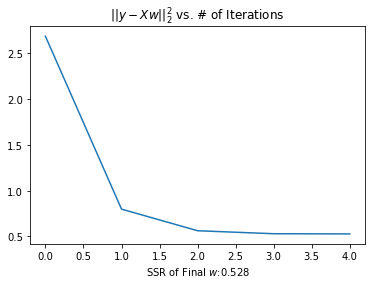

```
[36.08 -0.8   0.55 -0.3   2.2   1.76 -1.76  2.34  1.15 -0.29  0.68  1.97
 -1.01  0.57]
```

```python
lam1 = 0.01
lam2 = 0.005
w_p2_ = lambda R, J, W: (X_train_[:,J].T @ R - lam1*np.sign(W[J])) / (1+lam2)
w_p2, res_p2 = coordescent(w_p2_, max_iter=5)
plt.plot(res_p2)
plt.title(r'$||y-Xw||_{2}^{2}$ vs. # of Iterations')
plt.xlabel(r'SSR of Final $w$:%2.3f' %(res_p2[-1]))
plt.show()
print('Values of \'w\' at Convergence:')
print(np.round(w_p2,decimals=2))
```

```python
SAE_tst_p2 = np.sum(np.abs(y_test - X_test_ @ w_p2))
print('SAE of the Test Set: %3.3f' % SAE_tst_p2)
```

```
SAE of the Test Set: 4.994
```

## Topic 6

#### Proximal Gradient Descent

\begin{equation*} f(\mathbf{\theta }) =\underset{\mathbf{\theta }}{\min}\frac{1}{m}\sum _{i=1}^{m}[\log( 1+\exp(\mathbf{x}_{i}\mathbf{\theta })) -y_{i}\mathbf{x}_{i}\mathbf{\theta }] +\frac{\lambda _{2}}{2}\Vert \mathbf{\theta }\Vert _{2}^{2} +\lambda _{1}\Vert \mathbf{\theta }\Vert _{1} ,\ \text{where} \ y\in \{0,1\} \ \text{and} \ \lambda >0. \\ \text{if we define} \ g(\mathbf{\theta }) =\underset{\mathbf{\theta }}{\min}\frac{1}{m}\sum _{i=1}^{m}[\log( 1+\exp(\mathbf{x}_{i}\mathbf{\theta })) -y_{i}\mathbf{x}_{i}\mathbf{\theta }] +\frac{\lambda _{2}}{2}\Vert \mathbf{\theta }\Vert _{2}^{2} \ \text{as the convex and differentiable part,} \\ \text{and} \ h(\mathbf{\theta }) =\lambda _{1}\Vert \mathbf{\theta }\Vert _{1} \ \text{as the convex and non-differentiable part. We can solve the problem as:} \\ f(\mathbf{\theta }) =\ \arg\underset{z}{\min}\frac{1}{2t}\Vert z-(\mathbf{\theta } -t\nabla g(\mathbf{\theta }))\Vert _{2}^{2} +h( z) =\text{prox}_{t}(\mathbf{\theta } -t\nabla g(\mathbf{\theta })) ,\ \text{and} \ \mathbf{\theta }^{( k)} =\text{prox}_{t^{( k)}}\left(\mathbf{\theta }^{( k-1)} -t^{( k)} \nabla g\left(\mathbf{\theta }^{( k-1)}\right)\right) \\ \text{and for} \ \nabla g(\mathbf{\theta }) =\frac{\partial g(\mathbf{\theta })}{\partial \mathbf{\theta }} =\frac{1}{m}\sum _{i=1}^{m}\left[\frac{\mathbf{x}_{i}\exp(\mathbf{x}_{i}\mathbf{\theta })}{1+\exp(\mathbf{x}_{i}\mathbf{\theta })} -y_{i}\mathbf{x}_{i}\right] +\lambda _{2}\mathbf{\theta } ,\ \text{we get:} \end{equation*}\begin{equation*} \begin{aligned} \text{prox}_{t}(\mathbf{\theta } -t\nabla g(\mathbf{\theta })) & =\arg\underset{z}{\min}\frac{1}{2t}\left\Vert z-\left(\mathbf{\theta } -\frac{t}{m}\sum _{i=1}^{m}\left[\frac{\mathbf{x}_{i}\exp(\mathbf{x}_{i}\mathbf{\theta })}{1+\exp(\mathbf{x}_{i}\mathbf{\theta })} -y_{i}\mathbf{x}_{i}\right] +t\lambda _{2}\mathbf{\theta }\right)\right\Vert _{2}^{2} +\lambda _{1}\Vert z\Vert _{1}\\ \theta ^{( k+1)} & =S_{\lambda _{1} t}\left(\mathbf{\theta }^{( k)} +tx_{i}^{T}\left( y_{i} -\mathbf{x}_{i}\mathbf{\theta }^{( k)}\right)\right) \end{aligned} \end{equation*}

#### Implementation of Proximal Gradient Descent

```python
import numpy as np
from numpy import maximum as mxm, minimum as mnm
from sklearn.metrics import accuracy_score
import matplotlib.pyplot as plt
```

```python
data = np.loadtxt('Topic6.csv', delimiter=',')
X_trn, y_trn = data[:1000, :-1], data[:1000, -1]
X_tst, y_tst = data[1000:, :-1], data[1000:, -1]
```

```python
grad_inr = lambda x, y, thet: (x*np.exp(x*thet))/(1 + np.exp(x*thet))-x*y
predict = lambda x, thet, lamt: (1/(1 + np.exp(-x@thet)))>lamt
```

```python
def prox_grad(X_train, y_train, lam1, lam2, t, max_iter=10):
    acc_l = np.zeros(max_iter+1)
    theta = np.zeros(X_train.shape[1])
    acc_l[0] = accuracy_score(y_train, predict(X_train, theta, lam1*t))
    for i in range(max_iter):
        grad = np.array([
            grad_inr(X_train[j], y_train[j], theta) for j in
            range(y_train.size)]).sum(axis=0)/y_train.size + lam2*theta
        theta_ = theta - t*grad
        theta = mxm(theta_-t*lam1,0) + mnm(theta_+t*lam1,0)
        acc_l[i+1] = accuracy_score(y_train, predict(X_train, theta, lam1*t))

    print('Total non-negative weights:')
    print(np.sum(theta!=0))
    return theta, acc_l
```

```python
%%time
lam1 = 10
lam2 = 5
t = 2e-5
theta, acc_l = prox_grad(X_trn, y_trn, lam1, lam2, t, max_iter=40)
```

```
Total non-negative weights:
253
CPU times: total: 6.75 s
Wall time: 886 ms
```

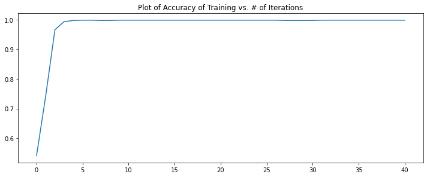

```python
plt.figure(figsize=(10,4)), plt.plot(acc_l), plt.tight_layout()
plt.title('Plot of Accuracy of Training vs. # of Iterations')
plt.show()
```

```python
y_tst_pred = predict(X_tst, theta, lam1*t)
test_acc = accuracy_score(y_tst, y_tst_pred)
print('Our model predicted the test set labels with',
      test_acc*100,'percent accuracy.\n '
      '(Misclassified only',(y_tst_pred!=y_tst).sum(),'element(s).)')
```

[output not shown]